# Changing Nature of Death in Infancy in the United States

Kevin Dysart

12/1/2019

# Introduction

- Infant mortality in the United States is a much discussed topic among population health policy makers and researchers.
  - Infant mortality rates are often associated with the health of nations across the world.
    - In the US much of infant mortality is amongst the most immature infants.
- Much of the recent conversation in neonatal medicine is on the increasing survival amongst infants born less than 1,500g (VLBW) or less than 32 weeks.
  - Recent studies have shown increases in survival amongst the smallest and most premature infants.
    - This is largely the result of therapeutic interventions introduced over the last 20 years and, potentially, more frequent applications to younger infants.
- Little information is available on how trends in care practices have impacted death in infancy.
  - Specifically among infants born VLBW and ELBW.

# Hypothesis

- Among infants born VLBW or ELBW there will be a temporal trend towrds increasing time before death.

# Data Sources

- Linked infant birth and death certificate data available from the National Bureau of Economic Reserach from **1995 through 2013**.
- CDC Wonder queries made throught the CDC Wonder website. **1995 through 2017**.
  - Of note there are 4 separate discrete time periods created by changes in birth or death certificate data.

# Infant Mortality Rate 1995

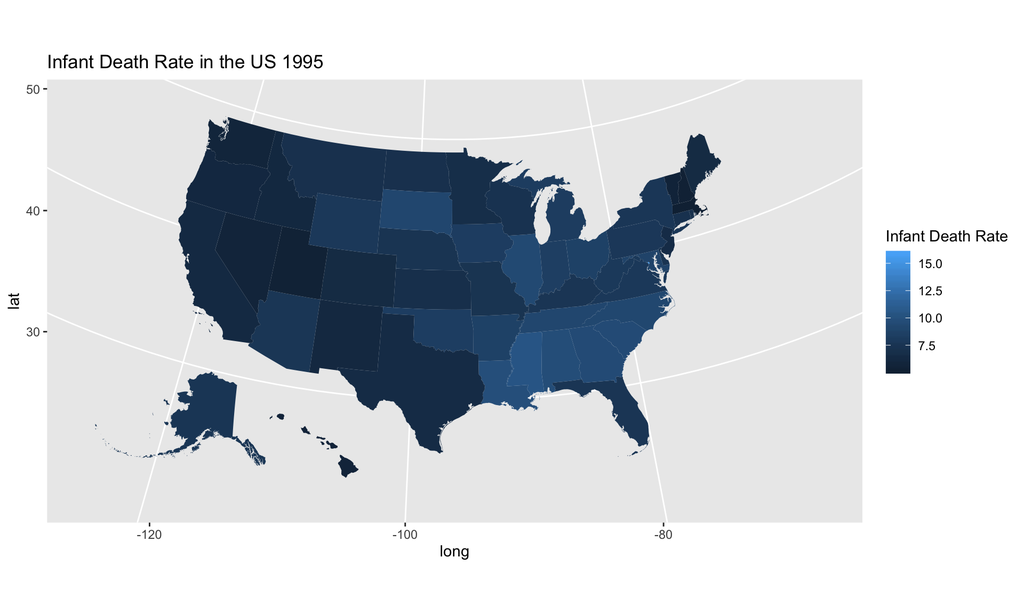

# Infant Mortality Rate 2007

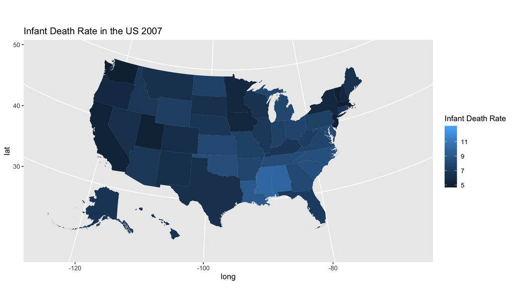

# Infant Mortality Rate 2017

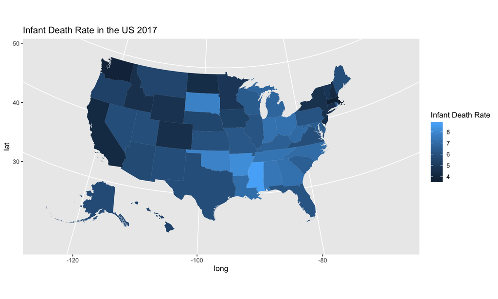

# What Portion of the IMR is Accounted for by VLBW Infants?

- In 1995 **48.4** percent of the IMR in the United States was accounted for by those infants born VLBW and **42.1** percent from infants born ELBW.
- By 2017 the percent of US infant mortality accounted for by VLBW infants rose to **53**. **46.9** percent of IMR is now from infants born ELBW.
- Interestingly in 1995 **16.9** percent of IMR was account for by infants 22 weeks or less and that percent also rose to **23.1** percent.
  - These infants, until recently, were considered non-viable and not offered support.

# Improvements in IMR in Infants 1,000 to 1,499g.

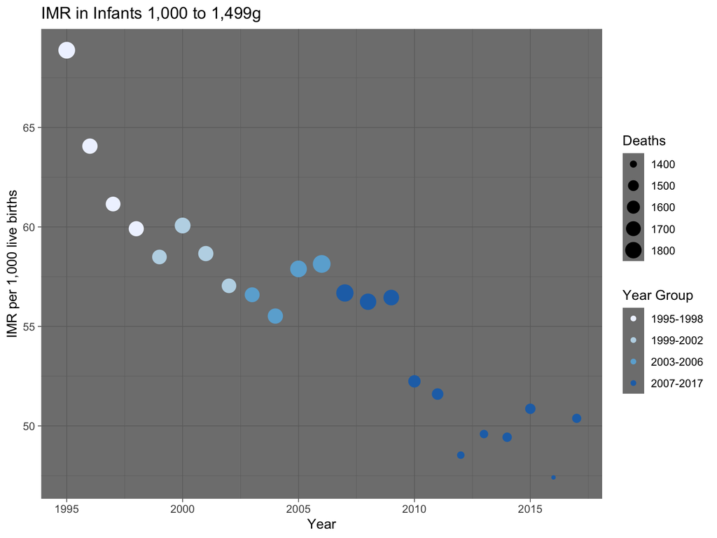

# Improvements in IMR in Infants 500-999g.

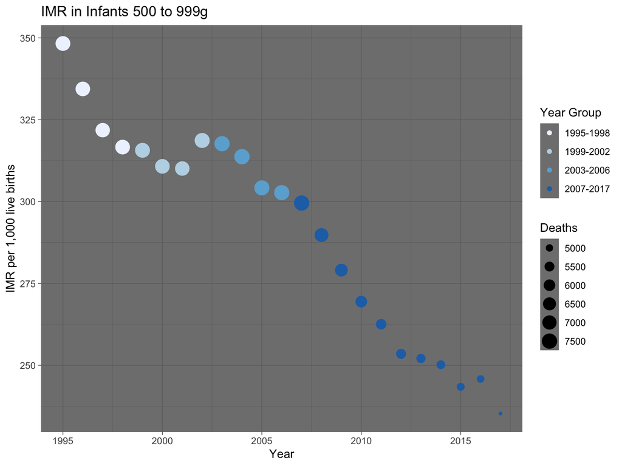

# Timing Prior to Death in Infacy Over Time for ELBW.

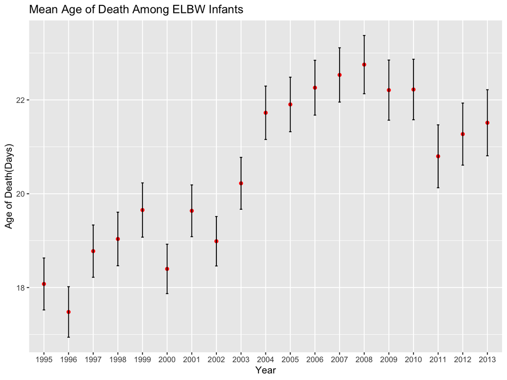

# Timing Prior to Death in Infacy Over Time for VLBW.

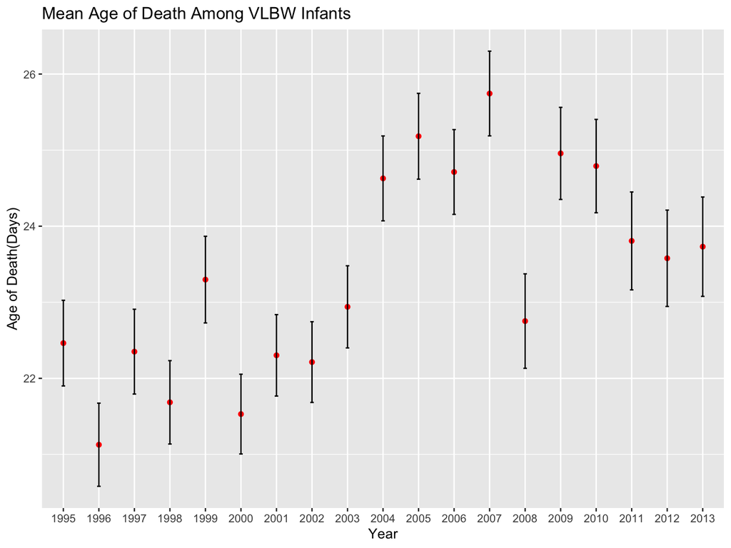

# Distribution of Time to Death for the Entire ELBW Cohort.

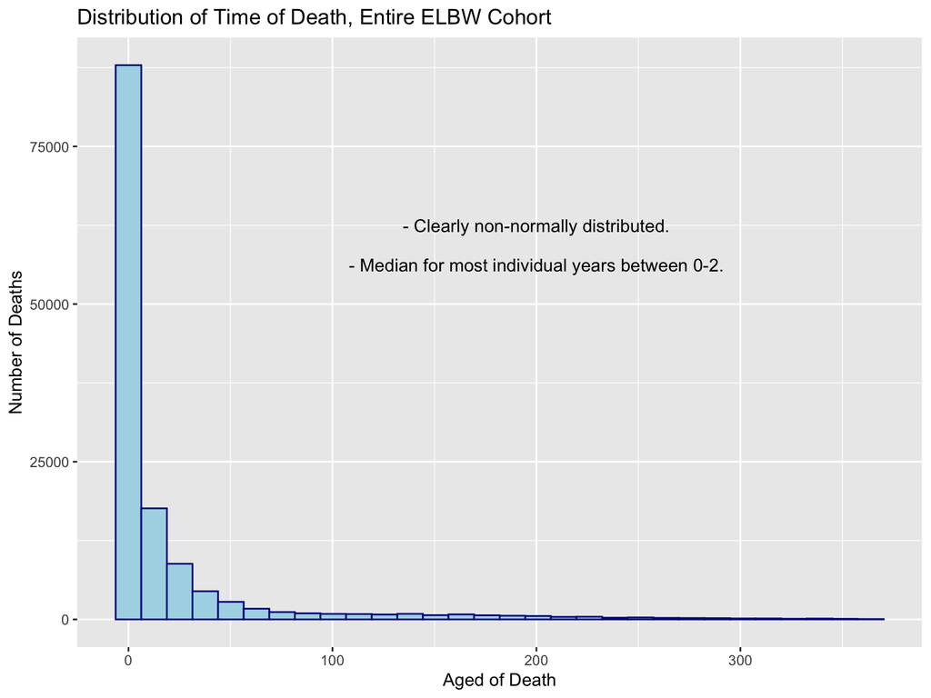

# Distribution of Time to Death for the Entire VLBW Cohort.

[figure not shown]

# Timing Prior to Death for ELBW Infants Survivng More Than 7d.

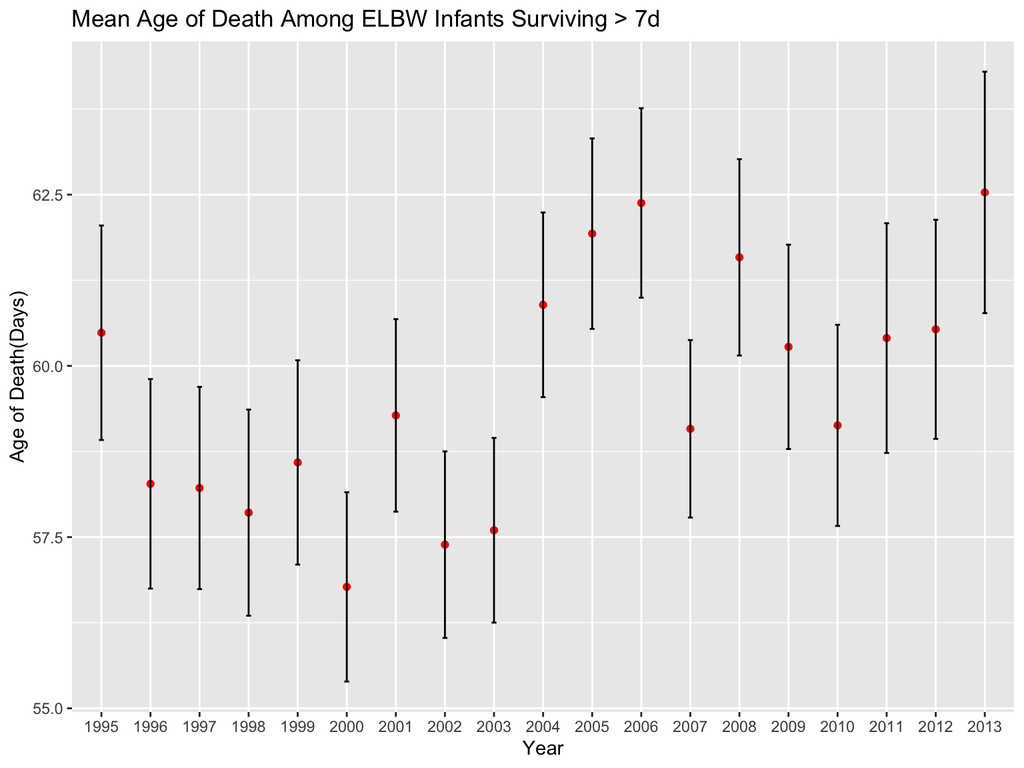

# Timing Prior to Death for VLBW Infants Survivng More Than 7d.

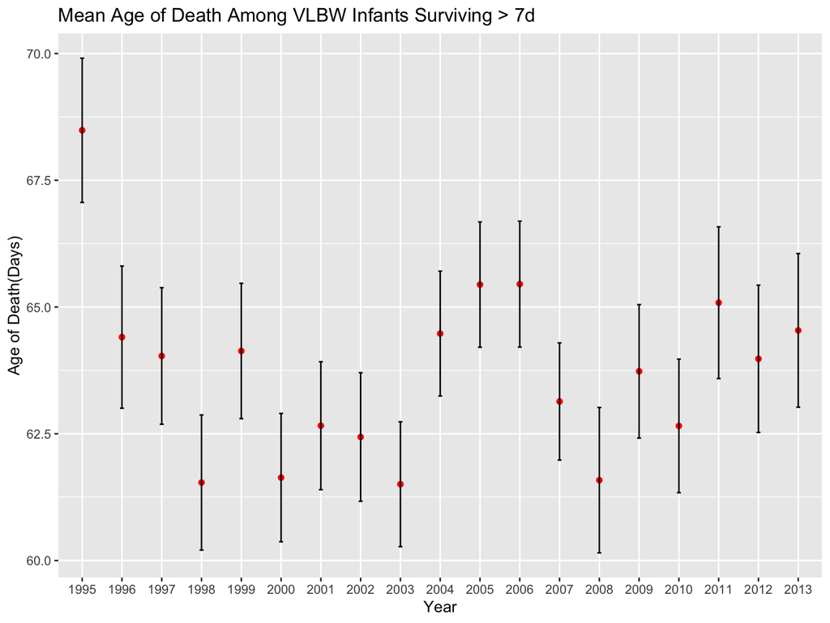

# Kaplan Meier Analysis 1995, 2007 and 2013 - Basic Survival Plot

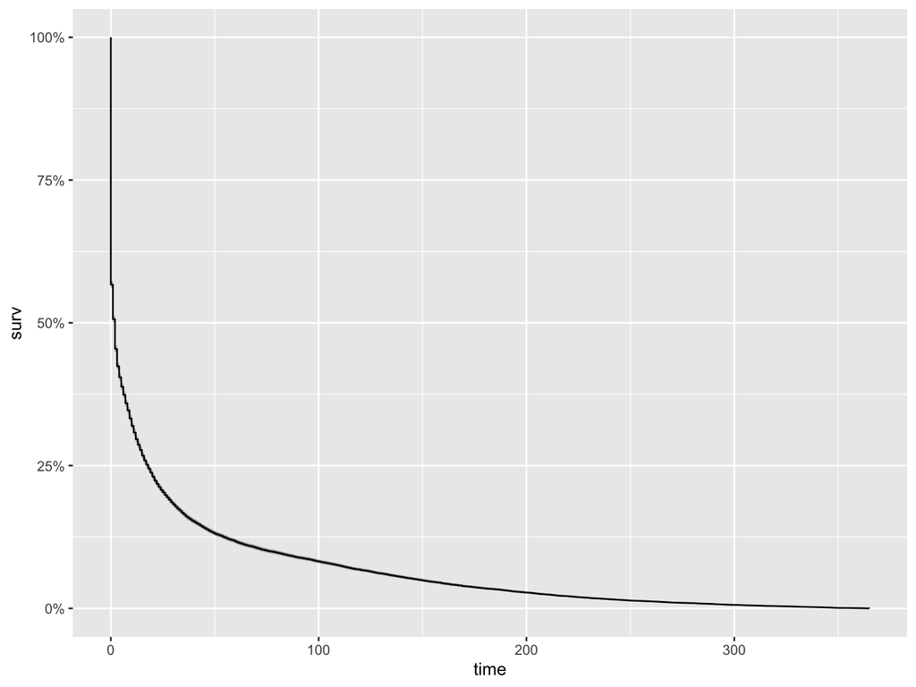

# Kaplan Meier Analysis 1995, 2007 and 2013 - Impact of Year

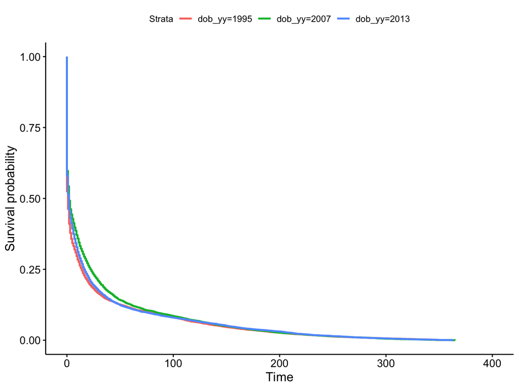

# Kaplan Meier Analysis 1995, 2007 and 2013 - Impact of Race

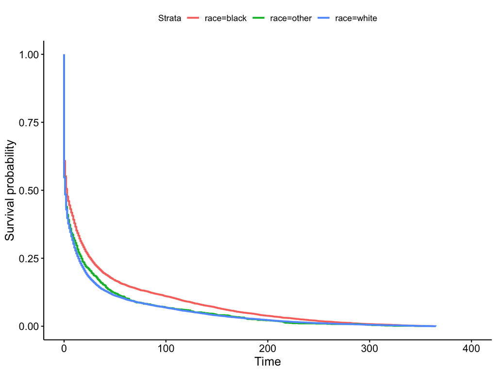

# Kaplan Meier Analysis 1995, 2007 and 2013 - Impact of Sex

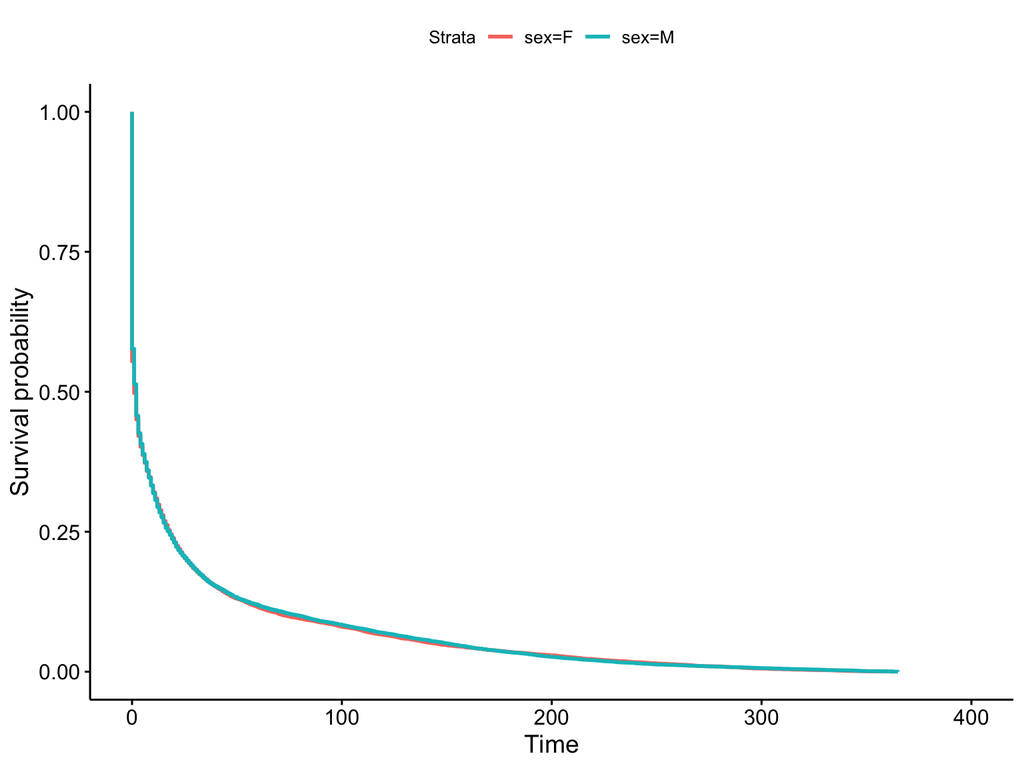

# Cox Proportional Hazard Model

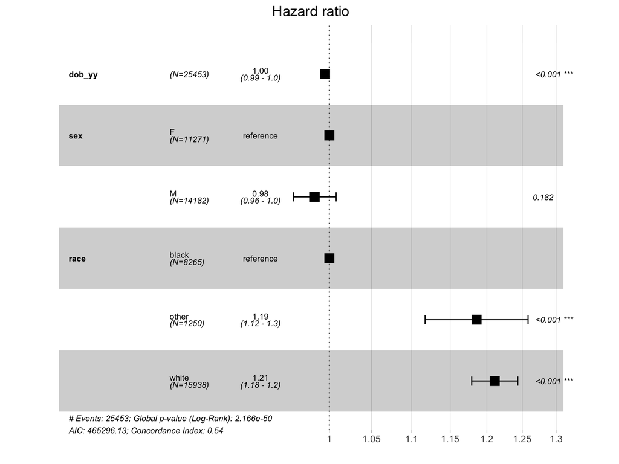

# Summary

- It appears that VLBW infants that died in infancy did see an increase in the time before death from **1995 through 2007**. _ However, timing more recently appears to be back to previous values.
  - This likely represents more infants living overall and not dying in infancy while those infants unlikely to respond to current therapies are dying early again.
    - Caffeine, CPAP, iNO may have have roles to play.
    - So may parental and health care giver attitudes towards resuscitation.
- Amongst the smallest birth weight infants there does seem to be an increasing time beofre death in the most recent era.
- African American infants appear to live longer then caucasian or other racial groups before death in infancy.